# Hands-on Practical: Generalised Linear Mixed Models GLMMs

StatGeoMod2025 — 1.5-hour practical

Emil Bogs

29 September 2025

## Part A – Loading and Exploring the Data (15 minutes)

### Task A1: Load the Data

**What you’ll do**: Load the owl data and convert some variables to the right type for analysis.

```r
# Load the data file - fill in the correct function name
owls <- read_table(file = "Owls.txt")

# Convert categorical variables to factors (R's way of handling categories)
owls <- owls %>%
  mutate(
    FoodTreatment = factor(owls$FoodTreatment),
    SexParent = factor(owls$SexParent),
    Nest = factor(owls$Nest)
  )

# Look at the structure of our data
summary(owls)
```

```
##           Nest      FoodTreatment  SexParent    ArrivalTime
##  Oleyes     : 52   Deprived:320   Female:245   Min.   :21.71
##  Montet     : 41   Satiated:279   Male  :354   1st Qu.:23.11
##  Etrabloz   : 34                               Median :24.38
##  Yvonnand   : 34                               Mean   :24.76
##  Champmartin: 30                               3rd Qu.:26.25
##  Lucens     : 29                               Max.   :29.25
##  (Other)    :379
##  SiblingNegotiation   BroodSize      NegPerChick
##  Min.   : 0.00      Min.   :1.000   Min.   :0.000
##  1st Qu.: 0.00      1st Qu.:4.000   1st Qu.:0.000
##  Median : 5.00      Median :4.000   Median :1.200
##  Mean   : 6.72      Mean   :4.392   Mean   :1.564
##  3rd Qu.:11.00      3rd Qu.:5.000   3rd Qu.:2.500
##  Max.   :32.00      Max.   :7.000   Max.   :8.500
##
```

```r
# Count how many observations we have per nest
nest <- owls %>%
          count(Nest) %>%
          arrange(desc(n)) %>%
          print(n = 10)
```

```
## # A tibble: 27 × 2
##    Nest            n
##    <fct>       <int>
##  1 Oleyes         52
##  2 Montet         41
##  3 Etrabloz       34
##  4 Yvonnand       34
##  5 Champmartin    30
##  6 Lucens         29
##  7 AutavauxTV     28
##  8 Marnand        27
##  9 Franex         26
## 10 Seiry          26
## # ℹ 17 more rows
```

**Questions to answer**:

1. How many total observations do we have? 599
2. How many different nests? 27
3. Which nest has the most observations? Oleyes

### Task A2: Transform the Response Variable

**What you’ll do**: Create a better version of our outcome variable for analysis.

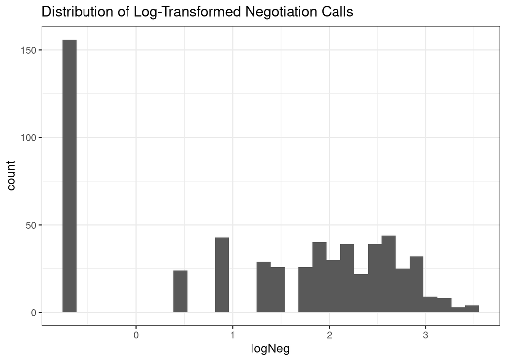

```r
# Create log-transformed version (helps with normality)
# We add 0.5 to handle any zero values
owls <- owls %>%
  mutate(logNeg = log(owls$SiblingNegotiation + 0.5))

# Check if this transformation helps make data more normal
ggplot(owls, aes(x = logNeg)) +
  geom_histogram(bins = 30) +
  labs(title = "Distribution of Log-Transformed Negotiation Calls")
```

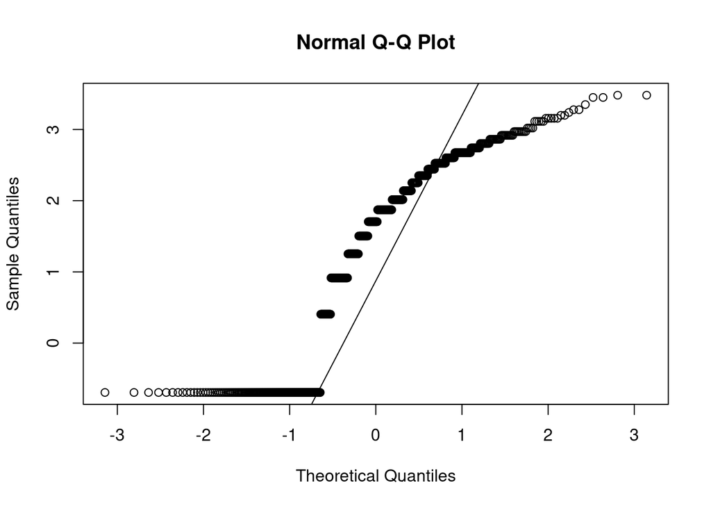

```r
# QQ plot to check normality
qqnorm(owls$logNeg)
qqline(owls$logNeg)
```

**Questions to answer**:

1. Does the histogram look approximately bell-shaped? Everythin looks more bell shape but a big pillar of ~ 155 counts around -0.6 logNeg.
2. In the QQ plot, do most points fall close to the line? The Points fall around the line for 0.5 to 2.8 Sample Quantiles but over and under they are quite far away from the line.

### Task A3: Visualize the Nesting Structure

**What you’ll do**: See how different nests respond to arrival time.

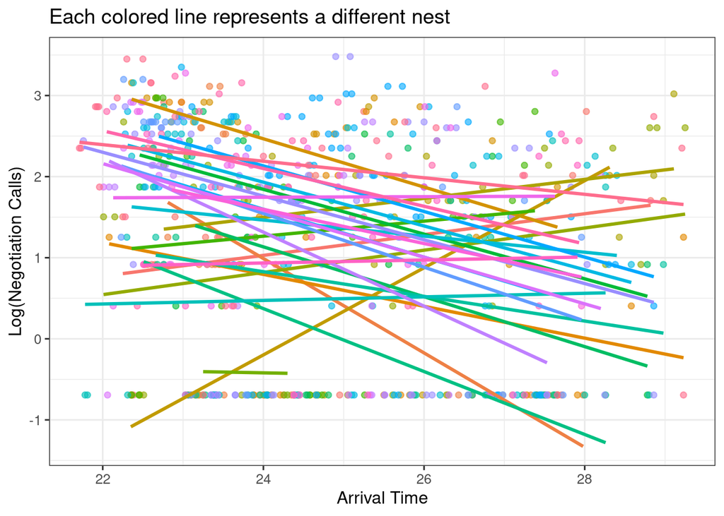

```r
# Plot showing relationship between arrival time and negotiation for each nest
ggplot(owls, aes(x = ArrivalTime, y = logNeg, color = Nest)) +
  geom_point(alpha = 0.6) +
  geom_smooth(method = "lm", se = FALSE) +
  guides(color = "none") +  # Hide legend (too many nests)
  labs(
    x = "Arrival Time",
    y = "Log(Negotiation Calls)",
    title = "Each colored line represents a different nest"
  )
```

**Questions to answer**:

1. Do all nests show similar slopes (parallel lines)? No a lot of them have diffrent slopes some positive some negative.
2. Do some nests have consistently higher negotiation levels than others? Yes some of them are consistenly high some increase over time to the same amount but somejust stay way lower.
3. What does this suggest about treating all observations as independent? It seems as if the Nests have an effect on the Response variable so we cant really treat them as independent.

## Part B – Why We Need Mixed Models (20 minutes)

### Task B1: The Wrong Way - Ignoring Nesting

**What you’ll do**: See what happens if we ignore the fact that observations come from different nests.

```r
# Fit a regular linear model that ignores nesting
simple_model <- lm(logNeg ~ ArrivalTime + FoodTreatment + SexParent + BroodSize,
                   data = owls)

summary(simple_model)
```

```
##
## Call:
## lm(formula = logNeg ~ ArrivalTime + FoodTreatment + SexParent +
##     BroodSize, data = owls)
##
## Residuals:
##     Min      1Q  Median      3Q     Max
## -2.7535 -1.0884  0.2029  0.9358  3.0845
##
## Coefficients:
##                       Estimate Std. Error t value Pr(>|t|)
## (Intercept)            3.92817    0.68122   5.766 1.30e-08 ***
## ArrivalTime           -0.14318    0.02593  -5.521 5.04e-08 ***
## FoodTreatmentSatiated -0.88304    0.09965  -8.862  < 2e-16 ***
## SexParentMale          0.24042    0.10123   2.375   0.0179 *
## BroodSize              0.27278    0.04331   6.299 5.83e-10 ***
## ---
## Signif. codes:  0 '***' 0.001 '**' 0.01 '*' 0.05 '.' 0.1 ' ' 1
##
## Residual standard error: 1.211 on 594 degrees of freedom
## Multiple R-squared:  0.2035, Adjusted R-squared:  0.1981
## F-statistic: 37.93 on 4 and 594 DF,  p-value: < 2.2e-16
```

**Question to answer**:

1. What is the coefficient for ArrivalTime? -0.14318

### Task B2: Another Wrong Way - Separate Analysis for Each Nest

**What you’ll do**: Fit separate models for each nest, then try to combine results.

```r
# Fit separate regression for each nest
nest_results <- owls %>%
  group_by(Nest) %>%
  do({
    # Fit model for this nest only
    model <- lm(logNeg ~ ArrivalTime, data = .)

    # Extract key information
    data.frame(
      slope = coef(model)["ArrivalTime"],
      intercept = coef(model)["(Intercept)"],
      n_obs = nrow(.)
    )
  }) %>%
  ungroup()

# Look at the results
print(nest_results, n = 15)
```

```
## # A tibble: 27 × 4
##    Nest              slope intercept n_obs
##    <fct>             <dbl>     <dbl> <int>
##  1 AutavauxTV       0.128    -2.05      28
##  2 Bochet          -0.582    15.0       23
##  3 Champmartin     -0.196     5.51      30
##  4 ChEsard         -0.298     9.61      20
##  5 Chevroux         0.537   -13.1       10
##  6 CorcellesFavres  0.117    -1.31      12
##  7 Etrabloz         0.137    -2.47      34
##  8 Forel           -0.0194    0.0455     4
##  9 Franex           0.0927   -0.960     26
## 10 GDLV            -0.276     8.46      10
## 11 Gletterens      -0.308     8.52      15
## 12 Henniez         -0.388     9.69      13
## 13 Jeuss           -0.152     4.48      19
## 14 LesPlanches      0.0220   -0.0540    17
## 15 Lucens          -0.0992    3.84      29
## # ℹ 12 more rows
```

```r
# Now try to relate slopes to food treatment
# First, get treatment for each nest
nest_treatments <- owls %>%
  distinct(FoodTreatment, Nest)

# Combine with our slope results
combined_results <- nest_results %>%
  left_join(nest_treatments, by = "Nest")

# Test if slopes differ by treatment
slope_model <- lm(slope ~ FoodTreatment, data = combined_results)
summary(slope_model)
```

```
##
## Call:
## lm(formula = slope ~ FoodTreatment, data = combined_results)
##
## Residuals:
##     Min      1Q  Median      3Q     Max
## -0.4339 -0.1454 -0.0627  0.1628  0.6853
##
## Coefficients:
##                         Estimate Std. Error t value Pr(>|t|)
## (Intercept)           -1.482e-01  4.461e-02  -3.321  0.00164 **
## FoodTreatmentSatiated  3.022e-17  6.309e-02   0.000  1.00000
## ---
## Signif. codes:  0 '***' 0.001 '**' 0.01 '*' 0.05 '.' 0.1 ' ' 1
##
## Residual standard error: 0.2318 on 52 degrees of freedom
## Multiple R-squared:  1.213e-32,  Adjusted R-squared:  -0.01923
## F-statistic: 6.308e-31 on 1 and 52 DF,  p-value: 1
```

**Questions to answer**:

1. Do all nests have the same number of observations? No they have diffrent amounts of observations.
2. Why might this be a problem when trying to compare slopes? Because we compare less accurate Data with more accurate Data.
3. What information are we throwing away by doing separate analyses? The fact that they come from diffrent sample sizes.

## Part C – Mixed Effects Models: The Right Way (25 minutes)

### Task C1: Random Intercept Model

**What you’ll do**: Fit a mixed model that allows each nest to have its own baseline level.

```r
# Fit mixed model with random intercepts for each nest
# (1 | Nest) means "let each nest have its own intercept"
model_ri <- lmer(logNeg ~ ArrivalTime + FoodTreatment + SexParent + BroodSize +
                   (1 | Nest),
                 data = owls,
                 REML = TRUE)

summary(model_ri)
```

```
## Linear mixed model fit by REML. t-tests use Satterthwaite's method [
## lmerModLmerTest]
## Formula: logNeg ~ ArrivalTime + FoodTreatment + SexParent + BroodSize +
##     (1 | Nest)
##    Data: owls
##
## REML criterion at convergence: 1913.7
##
## Scaled residuals:
##     Min      1Q  Median      3Q     Max
## -2.4646 -0.7482  0.1418  0.7118  2.4073
##
## Random effects:
##  Groups   Name        Variance Std.Dev.
##  Nest     (Intercept) 0.2181   0.467
##  Residual             1.3113   1.145
## Number of obs: 599, groups:  Nest, 27
##
## Fixed effects:
##                        Estimate Std. Error        df t value Pr(>|t|)
## (Intercept)             4.28669    0.73544 262.54728   5.829 1.63e-08 ***
## ArrivalTime            -0.14723    0.02531 586.41081  -5.816 9.91e-09 ***
## FoodTreatmentSatiated  -0.97492    0.09894 592.53308  -9.854  < 2e-16 ***
## SexParentMale           0.14978    0.10539 586.50656   1.421  0.15579
## BroodSize               0.23730    0.08431  22.50319   2.815  0.00996 **
## ---
## Signif. codes:  0 '***' 0.001 '**' 0.01 '*' 0.05 '.' 0.1 ' ' 1
##
## Correlation of Fixed Effects:
##             (Intr) ArrvlT FdTrtS SxPrnM
## ArrivalTime -0.863
## FdTrtmntStt -0.094  0.035
## SexParentMl -0.032 -0.052  0.069
## BroodSize   -0.496  0.028 -0.013 -0.032
```

**Questions to answer**:

1. What is the fixed effect coefficient for ArrivalTime? -0.147
2. What is the variance between nests? 0.2181
3. What is the residual variance? 1.3113

### Task C2: Random Intercept + Slope Model

**What you’ll do**: Allow each nest to have both its own baseline AND its own response to arrival time.

```r
# Fit mixed model with random intercepts AND slopes
# (1 + ArrivalTime | Nest) means "let each nest have its own intercept AND slope for ArrivalTime"
model_ris <- lmer(logNeg ~ ArrivalTime + FoodTreatment + SexParent + BroodSize +
                    (1 + ArrivalTime | Nest),
                  data = owls,
                  REML = TRUE)
summary(model_ris)
```

```
## Linear mixed model fit by REML. t-tests use Satterthwaite's method [
## lmerModLmerTest]
## Formula: logNeg ~ ArrivalTime + FoodTreatment + SexParent + BroodSize +
##     (1 + ArrivalTime | Nest)
##    Data: owls
##
## REML criterion at convergence: 1901.4
##
## Scaled residuals:
##     Min      1Q  Median      3Q     Max
## -2.6138 -0.7371  0.1677  0.7225  2.2784
##
## Random effects:
##  Groups   Name        Variance Std.Dev. Corr
##  Nest     (Intercept) 14.18285 3.7660
##           ArrivalTime  0.02254 0.1501   -0.99
##  Residual              1.24414 1.1154
## Number of obs: 599, groups:  Nest, 27
##
## Fixed effects:
##                        Estimate Std. Error        df t value Pr(>|t|)
## (Intercept)             4.31544    1.04814  28.58622   4.117 0.000297 ***
## ArrivalTime            -0.15235    0.03957  22.00931  -3.850 0.000868 ***
## FoodTreatmentSatiated  -0.96079    0.09779 587.77832  -9.825  < 2e-16 ***
## SexParentMale           0.17932    0.10353 569.45828   1.732 0.083817 .
## BroodSize               0.25041    0.07934  21.38927   3.156 0.004692 **
## ---
## Signif. codes:  0 '***' 0.001 '**' 0.01 '*' 0.05 '.' 0.1 ' ' 1
##
## Correlation of Fixed Effects:
##             (Intr) ArrvlT FdTrtS SxPrnM
## ArrivalTime -0.942
## FdTrtmntStt -0.058  0.015
## SexParentMl -0.012 -0.041  0.072
## BroodSize   -0.332  0.021 -0.016 -0.038
## optimizer (nloptwrap) convergence code: 0 (OK)
## Model failed to converge with max|grad| = 0.0611721 (tol = 0.002, component 1)
```

### Task C3: Compare the Two Models

**What you’ll do**: Statistically test which model fits better.

```r
# Compare the two models
anova(model_ri, model_ris)
```

```
## Data: owls
## Models:
## model_ri: logNeg ~ ArrivalTime + FoodTreatment + SexParent + BroodSize + (1 | Nest)
## model_ris: logNeg ~ ArrivalTime + FoodTreatment + SexParent + BroodSize + (1 + ArrivalTime | Nest)
##           npar    AIC    BIC  logLik -2*log(L)  Chisq Df Pr(>Chisq)
## model_ri     7 1910.8 1941.5 -948.39    1896.8
## model_ris    9 1903.1 1942.7 -942.56    1885.1 11.675  2   0.002917 **
## ---
## Signif. codes:  0 '***' 0.001 '**' 0.01 '*' 0.05 '.' 0.1 ' ' 1
```

**Questions to answer**:

1. What is the p-value for the comparison? 0.002917
2. Which model is significantly better? model_ris, because of a lower AIC and so on.
3. Should we use random slopes or just random intercepts? Accordingly i think we should use random slopes

## Part D – Understanding What Mixed Models Do (15 minutes)

### Task D1: Calculate Intraclass Correlation (ICC)

**What you’ll do**: Find out how much observations within the same nest resemble each other.

```r
# Extract variance components of the mixed model model
variance_components <- as.data.frame(VarCorr(model_ri))

# Get between-NEST variance
between_nest_var <- variance_components$vcov[variance_components$grp == "Nest"]

# Get within-nest variance  of the mixed model mode
within_nest_var <- sigma(model_ri)^2

# Calculate ICC (Intraclass Correlation Coefficient)
icc <- between_nest_var / (between_nest_var + within_nest_var)

cat("ICC =", round(icc, 3),
"\nThis means", round(icc * 100, 1), "% of variation is between nests")
```

```
## ICC = 0.143
## This means 14.3 % of variation is between nests
```

### Task D2: Visualize Model Predictions

**What you’ll do**: See how the model makes predictions for population vs individual nests.

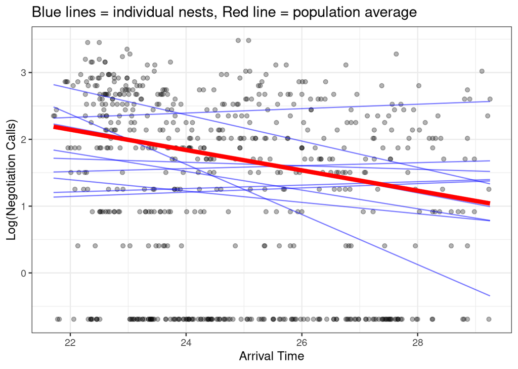

```r
# Create data for predictions
pred_data <- data.frame(
  ArrivalTime = seq(min(owls$ArrivalTime), max(owls$ArrivalTime), length.out = 100),
  FoodTreatment = factor("Deprived", levels = levels(owls$FoodTreatment)),
  SexParent = factor("Male", levels = levels(owls$SexParent)),
  BroodSize = median(owls$BroodSize)
)

# Population-level prediction (ignoring random effects)
pred_data$population_fit <- predict(model_ris, newdata = pred_data, re.form = NA)

# Create nest-specific predictions
# Create the data frame first
nest_data <- owls |>
  distinct(Nest) |>
  slice_head(n = 10) |>
  crossing(pred_data)

# Then add predictions
nest_predictions <- nest_data |>
  mutate(nest_fit = predict(model_ris, newdata = nest_data, re.form = ~ (1 + ArrivalTime | Nest)))

# Plot
ggplot() +
  geom_point(data = owls, aes(ArrivalTime, logNeg), alpha = 0.3) +
  geom_line(data = nest_predictions,
            aes(ArrivalTime, nest_fit, group = Nest),
            alpha = 0.5, color = "blue") +
  geom_line(data = pred_data,
            aes(ArrivalTime, population_fit),
            size = 2, color = "red") +
  labs(
    title = "Blue lines = individual nests, Red line = population average",
    x = "Arrival Time",
    y = "Log(Negotiation Calls)"
  )
```

**Questions to answer**:

1. Do the blue lines (individual nests) vary around the red line (population average)? Yes some are in average lower some higher, some have similar tendencies others show positive trends so opposite to the average.
2. Where is the variation between nests greatest - at early or late arrival times? The variation seems to be highest for late arrival times.

## Part E – Model Checking (15 minutes)

### Task E1: Check Model Assumptions

**What you’ll do**: Make sure our model is reasonable by checking the residuals.

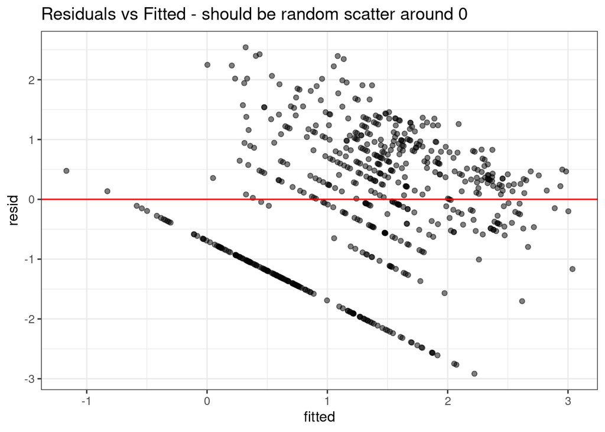

```r
# Choose our final model (let's assume random slopes was better)
final_model <- model_ris

# Get standardized residuals
residuals <- resid(final_model, type = "pearson")

# 1. Residuals vs fitted values
fitted_values <- fitted(final_model)
ggplot(data.frame(fitted = fitted_values, resid = residuals),
       aes(fitted, resid)) +
  geom_point(alpha = 0.5) +
  geom_hline(yintercept = 0, color = "red") +
  labs(title = "Residuals vs Fitted - should be random scatter around 0")
```

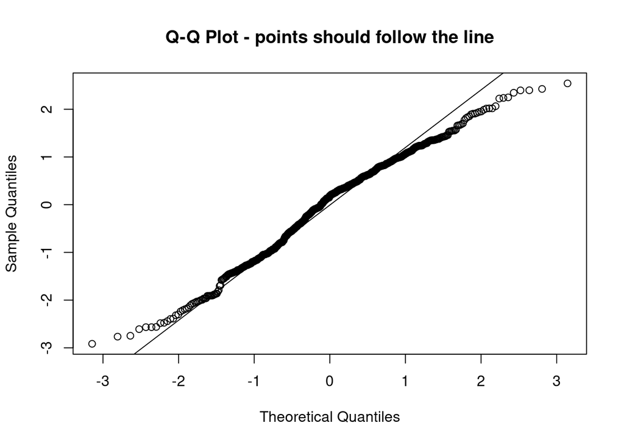

```r
# 2. Check normality of residuals
qqnorm(residuals, main = "Q-Q Plot - points should follow the line")
qqline(residuals)
```

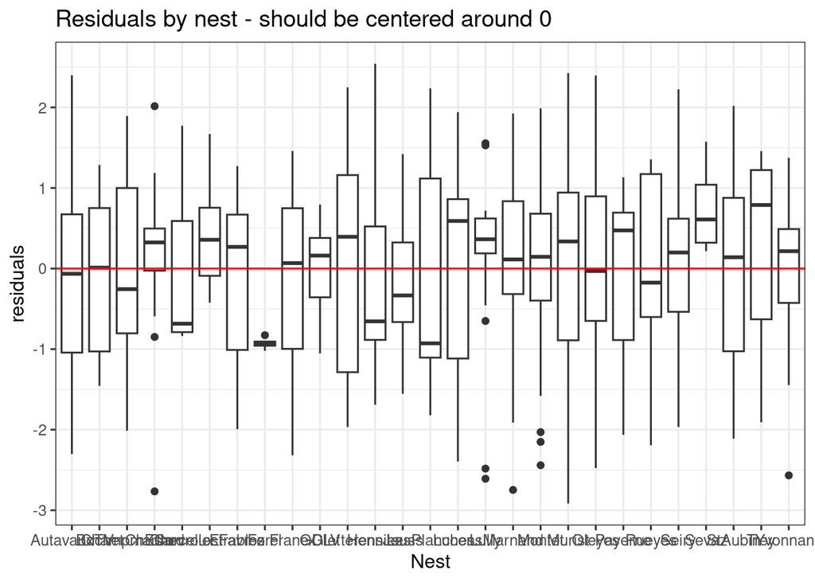

```r
# 3. Check residuals by nest
data.frame(Nest = owls$Nest, residuals = residuals) %>%
  ggplot(aes(residuals, Nest)) +
  geom_boxplot() +
  coord_flip() +
  geom_vline(xintercept = 0, color = "red") +
  labs(title = "Residuals by nest - should be centered around 0")
```

**Questions to answer**:

1. In the residuals vs fitted plot, do you see any clear patterns? The best scattering around o0 is for high fitted points and for very low because there are less Data Points. For fitted from 0 to 2 the scattering is highest.
2. In the QQ plot, do the residuals appear normally distributed? Yes because they are close to the line and there are less points for high and low points.
3. Are there any nests with unusual residual patterns? Forel has a very low variance and is strongly lower then the other ones. And there is Chesard and Lully with strong outliers.

### Task E2: Look at Random Effects

**What you’ll do**: See which nests are unusual.

```r
# Extract random effects (how each nest differs from average)
random_effects <- ranef(final_model)

# Look at first few
head(random_effects$Nest)
```

```
##                 (Intercept) ArrivalTime
## AutavauxTV       -4.8492683  0.17801682
## Bochet            5.1351997 -0.22289288
## Champmartin      -0.6223031  0.01257301
## ChEsard           1.5957196 -0.04450684
## Chevroux         -4.4662785  0.17450935
## CorcellesFavres  -3.8932249  0.18530135
```

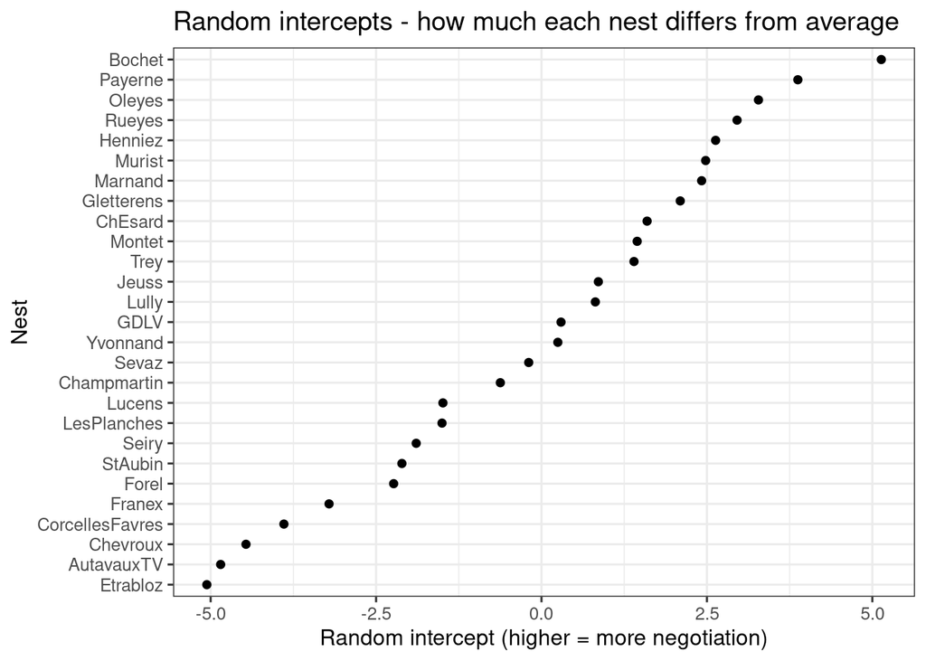

```r
# Make a caterpillar plot of random intercepts
re_data <- as.data.frame(random_effects$Nest) %>%
  mutate(Nest = rownames(.)) %>%
  rename(random_intercept ="(Intercept)")

ggplot(re_data, aes(x = reorder(Nest, random_intercept), y = random_intercept)) +
  geom_point() +
  coord_flip() +
  labs(
    title = "Random intercepts - how much each nest differs from average",
    x = "Nest",
    y = "Random intercept (higher = more negotiation)"
  )
```

**Questions to answer**:

1. Which nest has the highest random intercept? Bochet
2. Which nest has the lowest random intercept? Etrabloz
3. What does a positive random intercept mean? That thos enests show a higher response from the chickens to feeding then the average nest.

## Summary Questions

**Answer these questions based on your analysis**: